# NOAA Storm Database: the worst events

NOAA Storm Database Study: the worst events

In this study we have analysed the NOAA Storm Database in order to determine what are the worst natural catastrophic events, both in terms of public health and in economic impact.

The U.S. National Oceanic and Atmospheric Administration’s (NOAA) storm database tracks characteristics of major storms and weather events in the United States, including when and where they occur, as well as estimates of any fatalities, injuries, and property damage.

The database currently contains data from January 1950 to January 2017, as entered by NOAA’s National Weather Service (NWS).

The database can be found on:

https://www.ncdc.noaa.gov/stormevents/ftp.jsp

## Objective

The goal of this study is to answer the questions:

1. Across the United States, which types of events were the most harmful with respect to population health ever recorded in a single occurrence?
2. Which types of events caused most harm to population health along all those years?
3. Which types of events had the greatest economic consequences in a single occurrence?
4. Which types of events had the greatest economic consequences along all those years?

## Data Processing

Data Processing

This code loads the original data and them choose which variables are useful to answer our questions:

```r
library(scales)
library(data.table)
library(chron)
library(dplyr)
library(lubridate)
library(ggplot2)
library(rmarkdown)
library(RColorBrewer)
library(gridExtra)
library(grid)
```

```r
#fileUrl <- "https://d396qusza40orc.cloudfront.net/repdata%2Fdata%2FStormData.csv.bz2"

#download.file(fileUrl, "StormData.bz2", method = "curl")

#Full data
dados <- fread(sprintf("bzcat %s | tr -d '\\000'", "StormData.bz2"), na.strings = "")
```

```
##
Read 12.4% of 967216 rows
Read 35.2% of 967216 rows
Read 54.8% of 967216 rows
Read 70.3% of 967216 rows
Read 79.6% of 967216 rows
Read 92.0% of 967216 rows
Read 902297 rows and 37 (of 37) columns from 0.523 GB file in 00:00:08
```

```r
dados <-tbl_df(dados)

# this do a sample data base, with 50000 obs, used for speeding up initial works:
# linhas <- nrow(dados)
# linhas <- sample(linhas,50000)
# dataS <- dados[linhas,]
# write.csv(dataS, "StormData")
# dados <- fread(sprintf("bzcat %s | tr -d '\\000'", "StormData.bz2"))
# dados <-tbl_df(dados)
# dados <- select(dados, -1)



# treating var names
names(dados) <- gsub("_", ".", tolower(names(dados)))
names(dados)
```

```
##  [1] "state.."    "bgn.date"   "bgn.time"   "time.zone"  "county"
##  [6] "countyname" "state"      "evtype"     "bgn.range"  "bgn.azi"
## [11] "bgn.locati" "end.date"   "end.time"   "county.end" "countyendn"
## [16] "end.range"  "end.azi"    "end.locati" "length"     "width"
## [21] "f"          "mag"        "fatalities" "injuries"   "propdmg"
## [26] "propdmgexp" "cropdmg"    "cropdmgexp" "wfo"        "stateoffic"
## [31] "zonenames"  "latitude"   "longitude"  "latitude.e" "longitude."
## [36] "remarks"    "refnum"
```

This database has 902297 observations. Each observation corresponds to an event occurrence.

To determine the most harmful events to human health, we will check the variables related to human health, which are “fatalities” and “injuries”.

To determine the most harmful events to economy, we will check the variables related to economic measures, from “propdmg” through “cropdmgexp”.

Also, in order to analyse various occurrences of the same event, we will measure the duration of the event, its magnitude and where the event occurred (state and county name).

```r
# select desired vars
harm.df <- dados %>% select(evtype, mag, state, countyname, bgn.date, end.date, 23:28)

# treat vars
harm.df <- harm.df %>%
        mutate(bgn.date = mdy_hms(bgn.date), end.date = mdy_hms(end.date),
               day = as.Date(bgn.date, "%m/%d/%Y"),
               duration = -as.period(interval(end.date, bgn.date)),
               event = tolower(as.character(evtype)),
               countyname =strtrim(countyname,9)) %>%
        select(event, 2, day, duration, 3:4, 7:12)

# fixing exp for economic data
harm.df$propdmgexp[which(harm.df$propdmgexp=="K")] <- as.character(3)
harm.df$propdmgexp[which(harm.df$propdmgexp=="m")] <- as.character(6)
harm.df$propdmgexp[which(harm.df$propdmgexp=="M")] <- as.character(6)
harm.df$propdmgexp[which(harm.df$propdmgexp=="B")] <- as.character(9)
harm.df$propdmgexp <- as.numeric(harm.df$propdmgexp)

harm.df$cropdmgexp[which(harm.df$cropdmgexp=="K")] <- as.character(3)
harm.df$cropdmgexp[which(harm.df$cropdmgexp=="m")] <- as.character(6)
harm.df$cropdmgexp[which(harm.df$cropdmgexp=="M")] <- as.character(6)
harm.df$cropdmgexp[which(harm.df$cropdmgexp=="B")] <- as.character(9)
harm.df$cropdmgexp <- as.numeric(harm.df$cropdmgexp)

harm.df <- mutate(harm.df, prop.ev = propdmg*10^propdmgexp,
                crop.ev = cropdmg*10^cropdmgexp)
```

```r
# treating event types

eventos <- harm.df$event
# first, need to see what are the event types
contagem <- sort(table(eventos))

# them we create this list of terms

lista <- c(
"wind",
"winter",
"slide",
"snow",
"flood",
"cold|freez",
"hurricane",
"tornado",
"rain|precip",
"hail",
"heat|warm",
"tide",
"storm",
"record",
"blizzard",
"fire",
"funnel",
"surf")

for (i in 1:length(lista)) {
        eventos[grepl(lista[i], eventos)] <- lista[i]

}

# lets group the events whose count is < 5 and call it "other"
contagem <- sort(table(eventos))
outros <- names(contagem[contagem<5])
eventos[eventos %in% outros] <- "other"
# sort(table(eventos))

# returning treated events
harm.df$event <- toupper(eventos)

rm(dados) # house cleanning
```

## Human health: the most harmfull events

We have determined what events did more harm to human health.

There were occurrences that caused zero fatalities but a lot of injuries. The inverse is also true, so we did a separate analysis to fatal and non-fatal events.

### Fatal Occurrences

### Most fatal in a single occurrence

Most fatal in a single occurrence

In order to determine what were the most fatal events in a single occurrence, we need to see how fatalities are distributed along the occurrences.

```r
# subset original data
fatal.df <- harm.df %>%
                filter(!is.na(fatalities)) %>%
                select(1:7)


# quantiles
qt <- quantile(fatal.df$fatalities, probs=seq(.9,1,0.001))

# distribution plot

plt.distr.fatal0 <- ggplot(fatal.df, aes(fatalities))

plt.distr.fatal0 <- plt.distr.fatal0 + geom_density(aes(y=..density..)) + xlim(0,.5) +
        labs(title="All events") +
        theme(plot.title = element_text(hjust = 0.5))

# display only the qts next to fatal events
qt[(length(qt)-(length(qt[qt>=1])+1)): length(qt)]
```

```
##  99.1%  99.2%  99.3%  99.4%  99.5%  99.6%  99.7%  99.8%  99.9% 100.0%
##      0      0      1      1      1      1      1      2      3    583
```

Looking at this distribution, we can infer that the vast majority of those occurrences were not fatal at all: **99.2% occurrences didn’t caused any fatalities.**

On the other hand, fatal occurrences had to have at least 1 fatality.

Now, among the fatal occurrences, we are interested in the ones whose fatalities are beyond the confidence interval, ie. above 95% of the most common values.

```r
# subset for fatal events
fatal.df <- filter(fatal.df, fatalities > 0) %>%
                arrange(desc(fatalities)) %>%
                mutate(mean = mean(fatalities),
                median = median(fatalities),
                rank = seq_len(length(event)))


# quantiles, same as
# poisson.test(mean, conf.level = 0.95)

qt <- quantile(fatal.df$fatalities, probs=seq(.975,1,0.005))
qt
```

```
## 97.5%   98% 98.5%   99% 99.5%  100%
##    10    11    14    19    29   583
```

Distribution plots

```r
# distribution plot

plt.distr.fatal1 <- ggplot(fatal.df, aes(fatalities))

plt.distr.fatal1 <- plt.distr.fatal1 + geom_density(aes(y=..density..)) + xlim(0,qt[1]) +
        labs(title="Fatal events") +
        theme(plot.title = element_text(hjust = 0.5))
```

Looking at this distribution, we can infer that **95% of the fatal occurrences caused up to 10 fattalities**.

In this study, we looked on the 5% deadliest occurrences.

```r
# subset for 95% CI
fatal95.df <- fatal.df %>% filter(fatalities>qt[1])

# create color pallete for all events
colourCount.fatal.single = length(unique(fatal95.df$event))
getPalette = colorRampPalette(brewer.pal(colourCount.fatal.single, "Set1"))

# print a table
kable(fatal95.df[1:20, c(10,1:9)])
```

| rank | event | mag | day | duration | state | countyname | fatalities | mean | median |
| --- | --- | --- | --- | --- | --- | --- | --- | --- | --- |
| 1 | HEAT\|WARM | 0 | 1995-07-12 | 0S | IL | ILZ003>00 | 583 | 2.171638 | 1 |
| 2 | TORNADO | 0 | 2011-05-22 | 0S | MO | JASPER | 158 | 2.171638 | 1 |
| 3 | TORNADO | 0 | 1953-06-08 | NA | MI | GENESEE | 116 | 2.171638 | 1 |
| 4 | TORNADO | 0 | 1953-05-11 | NA | TX | MCLENNAN | 114 | 2.171638 | 1 |
| 5 | HEAT\|WARM | 0 | 1999-07-28 | 0S | IL | ILZ005>00 | 99 | 2.171638 | 1 |
| 6 | TORNADO | 0 | 1953-06-09 | NA | MA | WORCESTER | 90 | 2.171638 | 1 |
| 7 | TORNADO | 0 | 1955-05-25 | NA | KS | COWLEY | 75 | 2.171638 | 1 |
| 8 | HEAT\|WARM | 0 | 1999-07-04 | 0S | PA | PAZ054>05 | 74 | 2.171638 | 1 |
| 9 | HEAT\|WARM | 0 | 1995-07-01 | NA | PA | PAZ037>07 | 67 | 2.171638 | 1 |
| 10 | TORNADO | 0 | 1966-03-03 | NA | MS | HINDS | 57 | 2.171638 | 1 |
| 11 | HEAT\|WARM | 0 | 1995-07-13 | 0S | WI | WIZ005>07 | 57 | 2.171638 | 1 |
| 12 | TORNADO | 0 | 1952-03-21 | NA | AR | WHITE | 50 | 2.171638 | 1 |
| 13 | HEAT\|WARM | 0 | 2005-09-21 | 0S | TX | TXZ163 - | 49 | 2.171638 | 1 |
| 14 | HEAT\|WARM | 0 | 2006-07-16 | 0S | CA | CAZ089>09 | 46 | 2.171638 | 1 |
| 15 | TORNADO | 0 | 2011-04-27 | 0S | AL | TUSCALOOS | 44 | 2.171638 | 1 |
| 16 | TORNADO | 0 | 1979-04-10 | NA | TX | WICHITA | 42 | 2.171638 | 1 |
| 17 | HEAT\|WARM | 0 | 1999-07-18 | 0S | MO | MOZ009>01 | 42 | 2.171638 | 1 |
| 18 | HEAT\|WARM | 0 | 2006-08-01 | 0S | NY | NYZ067>08 | 42 | 2.171638 | 1 |
| 19 | TORNADO | 0 | 1953-12-05 | NA | MS | WARREN | 38 | 2.171638 | 1 |
| 20 | TORNADO | 0 | 1957-05-20 | NA | MO | JACKSON | 37 | 2.171638 | 1 |

```r
# prepare text for inline R
worst.fatal.single.ev <- fatal95.df$event[1]
worst.fatal.single.st <- fatal95.df$state[1]
worst.fatal.single.ct <- fatal95.df$countyname[1]
worst.fatal.single.dt <- fatal95.df$day[1]
worst.fatal.single.kill <- fatal95.df$fatalities[1]
```

```r
# the plot
plt.fatal.single <- ggplot(fatal95.df, aes(day, fatalities, colour=event))

plt.fatal.single <- plt.fatal.single + geom_point() +
        geom_text(aes(label=ifelse(rank <= 3,
                as.character(day),""),
                hjust=-.03,vjust=0.5)) +
        geom_hline(aes(yintercept = mean), linetype=2) +
        geom_hline(aes(yintercept = median), linetype=3) +
        labs(title="Most Fatal",
                    y="", x="") +

        expand_limits(x=as.Date('2017-01-01'))+ #ok
        scale_colour_manual(values = getPalette(colourCount.fatal.single))+
        theme(legend.title=element_blank()) +
        theme(legend.position="bottom") +
        guides(fill=guide_legend(nrow=5, byrow=TRUE)) +
        theme(axis.text.x = element_text(angle = 90, hjust = 1)) +
        theme(plot.title = element_text(hjust = 0.5))
```

The single most fatal event was a **HEAT|WARM, that occurred in IL, ILZ003>00, on 1995-07-12, killing 583 people.**

However, if we compare this single awful event to the mean of fatalities caused, we see that this is very unlikely to happen.

### Most fatal in all time

Most fatal in all time

Notice that are several occurrences of the same type of event along the time.

Therefore, in order to know which is the worst type of event along all the years, we summed up the fatalities caused by each one of occurrences of this events.

Notice that we are interested only in the worst of them, ie, the ones which are above the mean.

```r
# totals per event
fatal.all.df <- fatal.df %>% group_by(event) %>%
        summarise(total = sum(fatalities)) %>% arrange(desc(total)) %>%
        mutate(mean = mean(total), median = median(total),
               rank = seq_len(length(event))) %>%
        filter(total > mean(total))

# create color pallete for all events
colourCount.fatal.all = length(unique(fatal.all.df$event))
getPalette = colorRampPalette(brewer.pal(colourCount.fatal.all, "Set1"))

# prepare text for inline R
worst.fatal.all.ev <- fatal.all.df$event[1]
worst.fatal.all.kill <- fatal.all.df$total[1]

# a table
kable(fatal.all.df[,c(5,1:4)])
```

| rank | event | total | mean | median |
| --- | --- | --- | --- | --- |
| 1 | TORNADO | 5636 | 378.625 | 30.5 |
| 2 | HEAT\|WARM | 3178 | 378.625 | 30.5 |
| 3 | FLOOD | 1525 | 378.625 | 30.5 |
| 4 | WIND | 1451 | 378.625 | 30.5 |
| 5 | LIGHTNING | 816 | 378.625 | 30.5 |

```r
# the plot
plt.fatal.all <- ggplot(data=fatal.all.df, aes(event, total, fill=event))

plt.fatal.all <- plt.fatal.all + geom_bar(stat="identity") +
        geom_text(aes(label=ifelse(total==max(total),
                paste(event, max(total), sep=": "),'')),
                hjust=0,vjust=2) +
        geom_hline(aes(yintercept = mean), linetype=1) +
        geom_hline(aes(yintercept = median), linetype=2) +
        labs(title="All time", y="",
             x="") +

        theme(legend.position="none") +
        scale_colour_manual(values = getPalette(colourCount.fatal.all))+
        theme(legend.title=element_blank()) +
        theme(axis.text.x = element_text(angle = 90, hjust = 1)) +
        theme(plot.title = element_text(hjust = 0.5))
```

The most fatal event along the time is the **TORNADO. It has killed 5636 people until now.**

Just for curiosity, these are the less fatal among the fatal events:

```r
# sort for less dangerous, had to subset again due to previous filtering
fatal.all.df <- fatal.df %>% group_by(event) %>%
        summarise(total = sum(fatalities)) %>% arrange(total) %>%
        mutate(mean = mean(total), median = median(total),
               rank = seq(length(event),1, by=-1))

# a table
kable(fatal.all.df[1:10,c(5,1:2)])
```

| rank | event | total |
| --- | --- | --- |
| 40 | BLACK ICE | 1 |
| 39 | FROST | 1 |
| 38 | HIGH SWELLS | 1 |
| 37 | WINTRY MIX | 1 |
| 36 | DUST DEVIL | 2 |
| 35 | SLEET | 2 |
| 34 | DRY MICROBURST | 3 |
| 33 | HIGH WATER | 3 |
| 32 | WATERSPOUT | 3 |
| 31 | HIGH SEAS | 5 |

### Injuring Occurrences

### Most injuring in a single occurrence

Most injuring in a single occurrence

In order to determine what were the most injuring events in a single occurrence, we need to see how injuries are distributed along the occurrences.

```r
rm(fatal.df,fatal.all.df, fatal95.df, qt) # cleannig house


injuring.df <- harm.df %>% filter(!is.na(injuries)) %>%
                select(1:6,8)

# quantiles
qt <- quantile(injuring.df$injuries, probs=seq(.975,1,0.002))

# distribution plot
plt.distr.inj0 <- ggplot(injuring.df, aes(injuries))

plt.distr.inj0 <- plt.distr.inj0 + geom_density(aes(y=..density..)) + xlim(0,0.5) +
        labs(title="All events") +
        theme(plot.title = element_text(hjust = 0.5))


# display only the qts next to injuring events
qt[(length(qt)-(length(qt[qt>=1])+1)): length(qt)]
```

```
## 97.7% 97.9% 98.1% 98.3% 98.5% 98.7% 98.9% 99.1% 99.3% 99.5% 99.7% 99.9%
##     0     0     1     1     1     1     1     2     3     4     8    25
```

Looking at this distribution, we can infer that the vast majority of those occurrences were not injuring at all: **97.9% occurrences didn’t caused any injuries**

On the other hand, injuring occurrences had to have at least 1 injury.

Now, among the injuring occurrences, we are interested in the ones whose harm is beyond the confidence interval, ie. above 95% of the most common values.

```r
# subset for harm events
injuring.df <- injuring.df %>% filter(injuries > 0) %>%
                arrange(desc(injuries)) %>%
                mutate(mean = mean(injuries),
                median = median(injuries),
                rank = seq_len(length(event)))

# quantiles, same as
# poisson.test(mean, conf.level = 0.95)

qt <- quantile(injuring.df$injuries, probs=seq(.975,1,0.005))
qt
```

```
##    97.5%      98%    98.5%      99%    99.5%     100%
##   50.000   60.000   79.955  110.970  200.000 1700.000
```

Distribution plots

```r
# distribution plot
plt.distr.inj1 <- ggplot(injuring.df, aes(injuries))

plt.distr.inj1 <- plt.distr.inj1 + geom_density(aes(y=..density..)) + xlim(0,qt[1]) +
        labs(title="Injuring events") +
        theme(plot.title = element_text(hjust = 0.5))
```

Looking at this distribution, we can infer that **95% of the injuring occurrences caused up to 50 injuries**.

In this study, we looked on the 5% most injuring occurrences.

```r
# subset for 95% CI
injuring95.df <- filter(injuring.df, injuries>qt[1])

# create color pallete for all events
colourCount.inj.single = length(unique(injuring95.df$event))
getPalette = colorRampPalette(brewer.pal(colourCount.inj.single, "Set1"))

# print a table
kable(injuring95.df[1:20,c(10,1:9)])
```

| rank | event | mag | day | duration | state | countyname | injuries | mean | median |
| --- | --- | --- | --- | --- | --- | --- | --- | --- | --- |
| 1 | TORNADO | 0 | 1979-04-10 | NA | TX | WICHITA | 1700 | 7.982731 | 2 |
| 2 | STORM | 0 | 1994-02-08 | 0S | OH | OHZ42>088 | 1568 | 7.982731 | 2 |
| 3 | TORNADO | 0 | 1953-06-09 | NA | MA | WORCESTER | 1228 | 7.982731 | 2 |
| 4 | TORNADO | 0 | 1974-04-03 | NA | OH | GREENE | 1150 | 7.982731 | 2 |
| 5 | TORNADO | 0 | 2011-05-22 | 0S | MO | JASPER | 1150 | 7.982731 | 2 |
| 6 | FLOOD | 0 | 1998-10-17 | 0S | TX | COMAL | 800 | 7.982731 | 2 |
| 7 | TORNADO | 0 | 2011-04-27 | 0S | AL | TUSCALOOS | 800 | 7.982731 | 2 |
| 8 | TORNADO | 0 | 1953-06-08 | NA | MI | GENESEE | 785 | 7.982731 | 2 |
| 9 | HURRICANE | 0 | 2004-08-13 | 0S | FL | FLZ055 - | 780 | 7.982731 | 2 |
| 10 | FLOOD | 0 | 1998-10-17 | 0S | TX | TXZ206>20 | 750 | 7.982731 | 2 |
| 11 | TORNADO | 0 | 2011-04-27 | 0S | AL | JEFFERSON | 700 | 7.982731 | 2 |
| 12 | FLOOD | 0 | 1998-10-17 | 0S | TX | BEXAR | 600 | 7.982731 | 2 |
| 13 | TORNADO | 0 | 1953-05-11 | NA | TX | MCLENNAN | 597 | 7.982731 | 2 |
| 14 | TORNADO | 0 | 1965-04-11 | NA | IN | HOWARD | 560 | 7.982731 | 2 |
| 15 | FLOOD | 0 | 1998-10-17 | 0S | TX | TXZ205 - | 550 | 7.982731 | 2 |
| 16 | HEAT\|WARM | 0 | 2007-08-04 | 0S | MO | MOZ061 - | 519 | 7.982731 | 2 |
| 17 | TORNADO | 0 | 1966-03-03 | NA | MS | HINDS | 504 | 7.982731 | 2 |
| 18 | TORNADO | 0 | 1979-10-03 | NA | CT | HARTFORD | 500 | 7.982731 | 2 |
| 19 | TORNADO | 0 | 1967-04-21 | NA | IL | COOK | 500 | 7.982731 | 2 |
| 20 | TORNADO | 0 | 1970-05-11 | NA | TX | LUBBOCK | 500 | 7.982731 | 2 |

```r
# prepare text for inline R
worst.injuring.single.ev <- injuring95.df$event[1]
worst.injuring.single.st <- injuring95.df$state[1]
worst.injuring.single.ct <- injuring95.df$countyname[1]
worst.injuring.single.dt <- injuring95.df$day[1]
worst.injuring.single.inj <- injuring95.df$injuries[1]
```

```r
# the plot
plt.inj.single <- ggplot(injuring95.df, aes(day, injuries, colour=event))

plt.inj.single <- plt.inj.single + geom_point() +
        geom_text(aes(label=ifelse(rank <= 3,
                as.character(day),""),
                hjust=-.03,vjust=0.5)) +
        geom_hline(aes(yintercept = mean), linetype=2) +
        geom_hline(aes(yintercept = median), linetype=3) +
        labs(title="Most Injuring",
                    y="", x="") +

        expand_limits(x=as.Date('2017-01-01'))+ #ok
        scale_colour_manual(values = getPalette(colourCount.inj.single))+
        theme(legend.title=element_blank()) +
        theme(legend.position="bottom") +
        guides(fill=guide_legend(nrow=5, byrow=TRUE)) +
        theme(axis.text.x = element_text(angle = 90, hjust = 1)) +
        theme(plot.title = element_text(hjust = 0.5))
```

The single most injuring event was a **TORNADO, that occurred in TX, WICHITA, on 1979-04-10, injuring 1700 people.**

However, if we compare this single awful event to the mean of injuries caused, we see that this is very unlikely to happen.

### Most injuring in all time

Most injuring in all time

Notice that are several occurrences of the same type of event along the time.

Therefore, in order to know which is the worst type of event along all the years, we summed up the injuries caused by each one of occurrences of this events.

Notice that we are interested only in the worst of them, ie, the ones which are above the mean.

```r
# totals per event
injuring.all.df <- injuring.df %>% group_by(event) %>%
        summarise(total = sum(injuries)) %>%
        arrange(desc(total)) %>%
        mutate(mean = mean(total), median = median(total),
               rank = seq_len(length(event)))  %>%
        filter(total >= mean(total))

# create color pallete for all events
colourCount.inj.all = length(unique(injuring.all.df$event))
getPalette = colorRampPalette(brewer.pal(colourCount.inj.all, "Set1"))

# prepare text for inline R
worst.injuring.all.ev <- injuring.all.df$event[1]
worst.injuring.all.inj <- injuring.all.df$total[1]

# a table
kable(injuring.all.df[,c(5,1:4)])
```

| rank | event | total | mean | median |
| --- | --- | --- | --- | --- |
| 1 | TORNADO | 91407 | 3698.105 | 224 |
| 2 | WIND | 11498 | 3698.105 | 224 |
| 3 | HEAT\|WARM | 9243 | 3698.105 | 224 |
| 4 | FLOOD | 8604 | 3698.105 | 224 |
| 5 | LIGHTNING | 5230 | 3698.105 | 224 |

The most injuring event along the time is the **TORNADO. It has injuried 91407 people until now.**

```r
# the plot
plt.inj.all <- ggplot(data=injuring.all.df, aes(event, total, fill=event))

plt.inj.all <- plt.inj.all + geom_bar(stat="identity") +
        geom_text(aes(label=ifelse(total==max(total),
                paste(event, max(total), sep=": "),'')),
                hjust=0,vjust=2) +
        geom_hline(aes(yintercept = mean), linetype=1) +
        geom_hline(aes(yintercept = median), linetype=2) +
        labs(title="All time",
             y="", x="") +

        theme(legend.position="none") +
        scale_colour_manual(values = getPalette(colourCount.inj.all))+
        theme(legend.title=element_blank()) +
        theme(axis.text.x = element_text(angle = 90, hjust = 1)) +
        theme(plot.title = element_text(hjust = 0.5))
```

Just for curiosity, lets show now what are the less injuring among the injuring events:

```r
# sort for less dangerous, had to subset again due to previous filtering
injuring.all.df <- injuring.df %>% group_by(event) %>%
        summarise(total = sum(injuries)) %>% arrange(total) %>%
        mutate(mean = mean(total), median = median(total),
               rank = seq(length(event),1, by=-1))

# a table
kable(injuring.all.df[1:10,c(5,1:2)])
```

| rank | event | total |
| --- | --- | --- |
| 38 | FROST | 3 |
| 37 | FUNNEL | 3 |
| 36 | DROUGHT | 4 |
| 35 | TIDE | 5 |
| 34 | TYPHOON | 5 |
| 33 | HIGH SEAS | 8 |
| 32 | OTHER | 21 |
| 31 | BLACK ICE | 24 |
| 30 | DRY MICROBURST | 28 |
| 29 | WATERSPOUT | 29 |

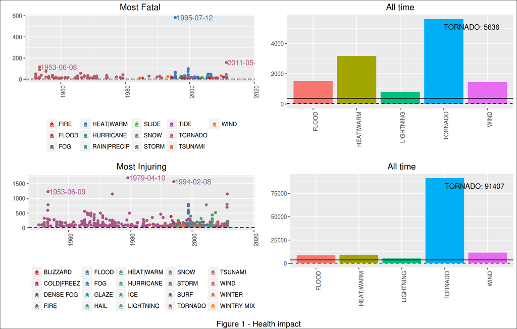

```r
# plist <- list(plt.fatal.single, plt.fatal.all, plt.inj.single, plt.inj.all)
# n <- length(plist)
# nCol <- floor(sqrt(n))
# do.call("grid.arrange", c(plist, ncol=nCol))


grid.arrange(plt.fatal.single, plt.fatal.all, plt.inj.single, plt.inj.all,
             nrow=2, ncol=2,
             bottom="Figure 1 - Health impact")
grid.rect(gp=gpar(fill=NA))
```

## Economy: the the most harmfull events

We have determined what events did more harm to economy, both in terms of property and crops damage.

There were events that causes zero property damage but a lot of crop damage. The inverse is also true, so we did a separate analysis to property VS crop damaging events.

### Property losses

### Most Property Damaging event in a single occurrence

Most Property Damaging event in a single occurrence

In order to determine what were the most property damaging events in a single occurrence, we need to see how damages are distributed along the occurrences.

```r
# property damages
rm(injuring.df, injuring.all.df, injuring95.df) # cleannig house

prop.df <- harm.df %>% filter(!is.na(prop.ev)) %>%
                        select(1:6,13)


# quantiles
qt <- quantile(prop.df$prop.ev, probs=seq(.975,1,0.002))

# distribution plot
plt.distr.prop0 <- ggplot(prop.df, aes(log(prop.ev)))

plt.distr.prop0 <- plt.distr.prop0 + geom_density(aes(y=..density..)) + #xlim(0,.5) +
        labs(title="All events", x="log(amount $)") +
        theme(plot.title = element_text(hjust = 0.5))


# display only the qts next to harmfull events
qt
```

```
##    97.5%    97.7%    97.9%    98.1%    98.3%    98.5%    98.7%    98.9%
##  1000000  1000000  1200000  1800000  2400000  2500000  2500000  3000000
##    99.1%    99.3%    99.5%    99.7%    99.9%
##  4700000  5000000 10000000 25000000 53931800
```

Looking at this distribution, we can infer that 95% of the occurrences caused less than **$1,000,000 in losses**.

On the other hand, damaging occurrences had to have damages above zero.

Now, among the damaging occurrences, we are interested in the ones whose damages are beyond the confidence interval, ie. above 95% of the most common values.

```r
# subset for harm events
prop.df <- prop.df %>% filter(prop.ev > 0) %>%
                arrange(desc(prop.ev)) %>%
                mutate(value = dollar(prop.ev),
                        media.raw = mean(prop.ev),
                        mediana.raw = median(prop.ev),
                        mean = dollar(media.raw),
                        median = dollar(mediana.raw),
                        rank = seq_len(length(event)))
# quantiles, same as

qt <- quantile(prop.df$prop.ev, probs=seq(.999,1,0.002))
qt
```

```
##     99.9%
## 120000000
```

Distribution plots

```r
# distribution plot
plt.distr.prop1 <- ggplot(prop.df, aes(log(prop.ev)))

plt.distr.prop1 <- plt.distr.prop1 + geom_density(aes(y=..density..)) + #xlim(0,100) +
        labs(title="Damaging events", x="log(amount $)") +
        theme(plot.title = element_text(hjust = 0.5))
```

In this study, we looked on the 0,1% most harmful occurrences.

```r
# subset for 95% CI
prop95.df <- filter(prop.df, prop.ev>qt[1])

# create color pallete for all events
colourCount.prop.single = length(unique(prop95.df$event))
getPalette = colorRampPalette(brewer.pal(colourCount.prop.single, "Set1"))


# print a table
kable(prop95.df[1:20,c(13,1:6,8,11:12)])
```

| rank | event | mag | day | duration | state | countyname | value | mean | median |
| --- | --- | --- | --- | --- | --- | --- | --- | --- | --- |
| 1 | FLOOD | 0 | 2006-01-01 | 0S | CA | NAPA | $115,000,000,000 | $1,791,099 | $10,000 |
| 2 | STORM | 0 | 2005-08-29 | 0S | LA | LAZ040 - | $31,300,000,000 | $1,791,099 | $10,000 |
| 3 | HURRICANE | 0 | 2005-08-28 | 0S | LA | LAZ034>04 | $16,930,000,000 | $1,791,099 | $10,000 |
| 4 | STORM | 0 | 2005-08-29 | 0S | MS | MSZ080>08 | $11,260,000,000 | $1,791,099 | $10,000 |
| 5 | HURRICANE | 0 | 2005-10-24 | 0S | FL | FLZ068>06 | $10,000,000,000 | $1,791,099 | $10,000 |
| 6 | HURRICANE | 0 | 2005-08-28 | 0S | MS | MSZ068>07 | $7,350,000,000 | $1,791,099 | $10,000 |
| 7 | HURRICANE | 0 | 2005-08-29 | 0S | MS | MSZ018>01 | $5,880,000,000 | $1,791,099 | $10,000 |
| 8 | HURRICANE | 0 | 2004-08-13 | 0S | FL | FLZ055 - | $5,420,000,000 | $1,791,099 | $10,000 |
| 9 | STORM | 0 | 2001-06-05 | 0S | TX | TXZ163>16 | $5,150,000,000 | $1,791,099 | $10,000 |
| 10 | WINTER | 0 | 1993-03-12 | 0S | AL | ALZ001>01 | $5,000,000,000 | $1,791,099 | $10,000 |
| 11 | FLOOD | 0 | 1993-08-31 | NA | IL | ADAMS, CA | $5,000,000,000 | $1,791,099 | $10,000 |
| 12 | HURRICANE | 0 | 2004-09-04 | 0S | FL | FLZ041 - | $4,830,000,000 | $1,791,099 | $10,000 |
| 13 | HURRICANE | 0 | 2004-09-13 | 0S | FL | FLZ001>00 | $4,000,000,000 | $1,791,099 | $10,000 |
| 14 | HURRICANE | 0 | 2005-09-23 | 0S | LA | LAZ027>03 | $4,000,000,000 | $1,791,099 | $10,000 |
| 15 | TIDE | 0 | 2008-09-12 | 0S | TX | TXZ213 - | $4,000,000,000 | $1,791,099 | $10,000 |
| 16 | FLOOD | 0 | 1997-04-18 | 0S | ND | NDZ027 | $3,000,000,000 | $1,791,099 | $10,000 |
| 17 | HURRICANE | 0 | 1999-09-15 | 0S | NC | NCZ007>01 | $3,000,000,000 | $1,791,099 | $10,000 |
| 18 | TORNADO | 0 | 2011-05-22 | 0S | MO | JASPER | $2,800,000,000 | $1,791,099 | $10,000 |
| 19 | RAIN\|PRECIP | 0 | 1995-05-08 | 0S | LA | LAFOURCHE | $2,500,000,000 | $1,791,099 | $10,000 |
| 20 | HURRICANE | 0 | 2004-09-13 | 0S | AL | ALZ051>06 | $2,500,000,000 | $1,791,099 | $10,000 |

```r
# prepare text for inline R
worst.prop.single.ev <- prop95.df$event[1]
worst.prop.single.st <- prop95.df$state[1]
worst.prop.single.ct <- prop95.df$countyname[1]
worst.prop.single.dt <- prop95.df$day[1]
worst.prop.single.value <- prop95.df$value[1]
```

```r
plt.prop.single <- ggplot(prop95.df, aes(day, prop.ev, colour=event))

plt.prop.single <- plt.prop.single + geom_point() +
        geom_text(aes(label=ifelse(rank <= 3,
                as.character(day),""),
                hjust=-.03,vjust=0.5)) +
        geom_hline(aes(yintercept = media.raw), linetype=2) +
         geom_hline(aes(yintercept = mediana.raw), linetype=3) +
        labs(title="Property Dammaging",
                    y="", x="") +

        expand_limits(x=as.Date('2017-01-01'))+ #ok
        scale_y_continuous(labels = dollar)+

        scale_colour_manual(values = getPalette(colourCount.prop.single))+
        theme(legend.title=element_blank()) +
        theme(legend.position="bottom") +
        guides(fill=guide_legend(nrow=5, byrow=TRUE)) +
        theme(axis.text.x = element_text(angle = 90, hjust = 1)) +
        theme(plot.title = element_text(hjust = 0.5))
```

The single most economic damaging event to properties was a **FLOOD, that occurred in CA, NAPA, on 2006-01-01, causing U$ $115,000,000,000 in losses**.

### Most Property Damaging event in all time

Most Property Damaging event in all time

Notice that are several occurrences of the same type of event along the time.

Therefore, in order to know which is the worst type of event along all the years, we summed up the losses caused by each one of occurrences of this events.

Notice that we are interested only in the worst of them, ie, the ones which are above the mean.

```r
# totals per event
prop.all.df <- prop.df %>% group_by(event) %>%
                summarise(total.raw = sum(prop.ev)) %>%
                arrange(desc(total.raw)) %>%
                mutate(media.raw = mean(total.raw),
                        mediana.raw = median(total.raw),
                        total = dollar(total.raw),
                        mean = dollar(media.raw),
                        median = dollar(mediana.raw),
                        rank = seq_len(length(event))) %>%
                filter(total.raw > mean(total.raw))

# create color pallete for all events
colourCount.prop.all = length(unique(prop.all.df$event))
getPalette = colorRampPalette(brewer.pal(colourCount.prop.all, "Set1"))

# prepare text for inline R
worst.prop.all.ev <- prop.all.df$event[1]
worst.prop.total <- prop.all.df$total[1]

# a table
kable(prop.all.df[, c(8,1,5:7)])
```

| rank | event | total | mean | median |
| --- | --- | --- | --- | --- |
| 1 | FLOOD | $168,200,584,588 | $8,739,282,968 | $9,353,700 |
| 2 | HURRICANE | $84,656,180,010 | $8,739,282,968 | $9,353,700 |
| 3 | TORNADO | $57,003,317,814 | $8,739,282,968 | $9,353,700 |
| 4 | STORM | $56,197,366,960 | $8,739,282,968 | $9,353,700 |
| 5 | WIND | $17,951,211,793 | $8,739,282,968 | $9,353,700 |
| 6 | HAIL | $15,977,047,956 | $8,739,282,968 | $9,353,700 |

```r
plt.prop.all <- ggplot(data=prop.all.df, aes(event, total.raw, fill=event))

plt.prop.all <- plt.prop.all + geom_bar(stat="identity") +

        geom_text(aes(label=ifelse(total.raw==max(total.raw),
                paste(event, dollar(max(total.raw)), sep=": "),'')),
                hjust=0,vjust=2) +
        geom_hline(aes(yintercept = media.raw), linetype=1) +
        geom_hline(aes(yintercept = mediana.raw), linetype=2) +
        labs(title="All time", y="", x="") +

        scale_y_continuous(labels = dollar)+

        theme(legend.position="none") +
        scale_colour_manual(values = getPalette(colourCount.prop.all))+
        theme(legend.title=element_blank()) +
        theme(axis.text.x = element_text(angle = 90, hjust = 1)) +
        theme(plot.title = element_text(hjust = 0.5))
```

The most property damaging event along the time is the **FLOOD. It has caused $168,200,584,588 in losses.**

Just for curiosity, these are the less damaging events:

```r
prop.all.df <- prop.df %>% group_by(event) %>%
                summarise(total.raw = sum(prop.ev)) %>%
                arrange(total.raw) %>%
                mutate(media.raw = mean(total.raw),
                        mediana.raw = median(total.raw),
                        total = dollar(total.raw),
                        mean = dollar(media.raw),
                        median = dollar(mediana.raw),
                        rank = seq(length(event),1, by=-1))



kable(prop.all.df[1:10, c(8,1,5:7)])
```

| rank | event | total | mean | median |
| --- | --- | --- | --- | --- |
| 49 | RIP CURRENT | $1,000 | $8,739,282,968 | $9,353,700 |
| 48 | HIGH SWELLS | $5,000 | $8,739,282,968 | $9,353,700 |
| 47 | URBAN/SMALL STREAM | $5,000 | $8,739,282,968 | $9,353,700 |
| 46 | WINTRY MIX | $12,500 | $8,739,282,968 | $9,353,700 |
| 45 | FROST | $15,000 | $8,739,282,968 | $9,353,700 |
| 44 | HIGH SEAS | $15,500 | $8,739,282,968 | $9,353,700 |
| 43 | WET MICROBURST | $35,000 | $8,739,282,968 | $9,353,700 |
| 42 | MICROBURST | $80,000 | $8,739,282,968 | $9,353,700 |
| 41 | DENSE SMOKE | $100,000 | $8,739,282,968 | $9,353,700 |
| 40 | GUSTNADO | $102,050 | $8,739,282,968 | $9,353,700 |

### Crop losses

### Most Crop Damaging event in a single occurrence

Most Crop Damaging event in a single occurrence

In order to determine what were the most crop damaging events in a single occurrence, we need to see how damages are distributed along the occurrences.

```r
# crop damages
rm(prop.df, prop.all.df, prop95.df) # cleannig house

crop.df <- harm.df %>% filter(!is.na(crop.ev)) %>%
                select(1:6,14)


# quantiles
qt <- quantile(crop.df$crop.ev, probs=seq(.975,1,0.002))

# distribution plot
plt.distr.crop0 <- ggplot(crop.df, aes(log(crop.ev)))

plt.distr.crop0 <- plt.distr.crop0 + geom_density(aes(y=..density..)) + #xlim(0,.5) +
        labs(title="All events", x="log(amount $)") +
        theme(plot.title = element_text(hjust = 0.5))


# display only the qts next to harmfull events
qt
```

```
##    97.5%    97.7%    97.9%    98.1%    98.3%    98.5%    98.7%    98.9%
##    50000    50000    80000   100000   100000   200000   250000   300000
##    99.1%    99.3%    99.5%    99.7%    99.9%
##   500000   750000  1200000  4000000 20000000
```

Looking at this distribution, we can infer that 95% of the occurrences caused less than **$50,000 in losses**.

On the other hand, damaging occurrences had to have damages above zero.

Now, among the damaging occurrences, we are interested in the ones whose damages are beyond the confidence interval, ie. above 95% of the most common values.

```r
# subset for harm events
crop.df <- crop.df %>% filter(crop.ev > 0) %>%
                arrange(desc(crop.ev)) %>%
                mutate(value = dollar(crop.ev),
                        media.raw = mean(crop.ev),
                        mediana.raw = median(crop.ev),
                        mean = dollar(media.raw),
                        median = dollar(mediana.raw),
                        rank = seq_len(length(event)))

# quantiles, same as
# poisson.test(mean, conf.level = 0.95)

qt <- quantile(crop.df$crop.ev, probs=seq(.975,1,0.005))
qt
```

```
##      97.5%        98%      98.5%        99%      99.5%       100%
##    7015000   11980800   20000000   30000000   65000000 5000000000
```

Distribution plots

```r
# distribution plot
plt.distr.crop1 <- ggplot(crop.df, aes(log(crop.ev)))

plt.distr.crop1 <- plt.distr.crop1 + geom_density(aes(y=..density..)) + #xlim(0,qt[1]) +
        labs(title="Damaging events", x="log(amount $)") +
        # scale_x_continuous(labels = dollar)+
        # theme(axis.text.x = element_text(angle = 90, hjust = 1)) +
        theme(plot.title = element_text(hjust = 0.5))
```

Looking at this distribution, we can infer that **95% of the damaging occurrences caused up to $7,015,000 in losses.**

In this study, we looked on the 5% most harmful occurrences.

```r
# subset for 95% CI
crop95.df <- filter(crop.df, crop.ev>qt[1])

# create color pallete for all events
colourCount.crop.single = length(unique(crop95.df$event))
getPalette = colorRampPalette(brewer.pal(colourCount.crop.single, "Set1"))


# print a table
kable(crop95.df[1:20,c(13,1:6,8,11:12)])
```

| rank | event | mag | day | duration | state | countyname | value | mean | median |
| --- | --- | --- | --- | --- | --- | --- | --- | --- | --- |
| 1 | FLOOD | 0 | 1993-08-31 | NA | IL | ADAMS, CA | $5,000,000,000 | $2,224,406 | $15,000 |
| 2 | STORM | 0 | 1994-02-09 | 0S | MS | MSZ001 - | $5,000,000,000 | $2,224,406 | $15,000 |
| 3 | HURRICANE | 0 | 2005-08-29 | 0S | MS | MSZ018>01 | $1,510,000,000 | $2,224,406 | $15,000 |
| 4 | DROUGHT | 0 | 2006-01-01 | 0S | TX | TXZ091>09 | $1,000,000,000 | $2,224,406 | $15,000 |
| 5 | COLD\|FREEZ | 0 | 1998-12-20 | 0S | CA | CAZ020>02 | $596,000,000 | $2,224,406 | $15,000 |
| 6 | DROUGHT | 0 | 2001-08-01 | 0S | IA | IAZ004>00 | $578,850,000 | $2,224,406 | $15,000 |
| 7 | DROUGHT | 0 | 2000-11-01 | 0S | TX | TXZ021>04 | $515,000,000 | $2,224,406 | $15,000 |
| 8 | DROUGHT | 0 | 1995-08-01 | 0S | IA | IAZ004>01 | $500,000,000 | $2,224,406 | $15,000 |
| 9 | DROUGHT | 0 | 1998-07-06 | 0S | OK | OKZ049 - | $500,000,000 | $2,224,406 | $15,000 |
| 10 | HURRICANE | 0 | 1999-09-15 | 0S | NC | NCZ007>01 | $500,000,000 | $2,224,406 | $15,000 |
| 11 | DROUGHT | 0 | 1999-07-01 | 0S | PA | PAZ006 - | $500,000,000 | $2,224,406 | $15,000 |
| 12 | FLOOD | 0 | 2000-10-03 | 0S | FL | FLZ072 - | $500,000,000 | $2,224,406 | $15,000 |
| 13 | FLOOD | 0 | 2007-07-01 | 0S | MO | HENRY | $500,000,000 | $2,224,406 | $15,000 |
| 14 | HEAT\|WARM | 0 | 2006-07-16 | 0S | CA | CAZ089>09 | $492,400,000 | $2,224,406 | $15,000 |
| 15 | DROUGHT | 0 | 2002-12-01 | 0S | NE | NEZ039>04 | $480,000,000 | $2,224,406 | $15,000 |
| 16 | DROUGHT | 0 | 1998-12-01 | 0S | TX | TXZ021>04 | $450,000,000 | $2,224,406 | $15,000 |
| 17 | HURRICANE | 0 | 2005-08-25 | 0S | FL | FLZ068 - | $423,000,000 | $2,224,406 | $15,000 |
| 18 | DROUGHT | 0 | 2001-12-01 | 0S | TX | TXZ021>04 | $420,000,000 | $2,224,406 | $15,000 |
| 19 | HURRICANE | 0 | 1999-09-14 | 0S | NC | NCZ029 - | $413,600,000 | $2,224,406 | $15,000 |
| 20 | HEAT\|WARM | 0 | 1995-08-20 | NA | AL | TALLADEGA | $400,000,000 | $2,224,406 | $15,000 |

```r
worst.crop.single.ev <- crop95.df$event[1]
worst.crop.single.st <- crop95.df$state[1]
worst.crop.single.ct <- crop95.df$countyname[1]
worst.crop.single.dt <- crop95.df$day[1]
worst.crop.single.value <- crop95.df$value[1]
```

```r
plt.crop.single <- ggplot(crop95.df, aes(day, crop.ev, colour=event))

plt.crop.single <- plt.crop.single + geom_point() +
        geom_text(aes(label=ifelse(rank <= 3,
                as.character(day),""),
                hjust=-.03,vjust=0.5)) +
        geom_hline(aes(yintercept = media.raw), linetype=2) +
        geom_hline(aes(yintercept = mediana.raw), linetype=3) +
        labs(title="Crop Dammaging",
                    y="", x="") +

        expand_limits(x=as.Date('2017-01-01'))+ #ok
        scale_y_continuous(labels = dollar)+

        scale_colour_manual(values = getPalette(colourCount.crop.single))+
        theme(legend.title=element_blank()) +
        theme(legend.position="bottom") +
        guides(fill=guide_legend(nrow=5, byrow=TRUE)) +
        theme(axis.text.x = element_text(angle = 90, hjust = 1)) +
        theme(plot.title = element_text(hjust = 0.5))
```

The single most economic damaging event to crops was a **FLOOD, that occurred in IL, ADAMS, CA, on 1993-08-31, causing U$ $5,000,000,000 in losses.**

### Most Crop Damaging event in all time

Most Crop Damaging event in all time

Notice that are several occurrences of the same type of event along the time.

Therefore, in order to know which is the worst type of event along all the years, we summed up the losses caused by each one of occurrences of this events.

Notice that we are interested only in the worst of them, ie, the ones which are above the mean.

```r
# totals per event
crop.all.df <- crop.df %>% group_by(event) %>%
                summarise(total.raw = sum(crop.ev)) %>%
                arrange(desc(total.raw)) %>%
                mutate(media.raw = mean(total.raw),
                        mediana.raw = median(total.raw),
                        total = dollar(total.raw),
                        mean = dollar(media.raw),
                        median = dollar(mediana.raw),
                        rank = seq_len(length(event))) %>%
                filter(total.raw > mean(total.raw))

# create color pallete for all events
colourCount.crop.all = length(unique(crop.all.df$event))
getPalette = colorRampPalette(brewer.pal(colourCount.crop.all, "Set1"))

# prepare text for inline R
worst.crop.all.ev <- crop.all.df$event[1]
worst.crop.total <- crop.all.df$total[1]

# a table
kable(crop.all.df[, c(8,1,5:7)])
```

| rank | event | total | mean | median |
| --- | --- | --- | --- | --- |
| 1 | DROUGHT | $13,972,566,000 | $2,045,989,840 | $162,349,150 |
| 2 | FLOOD | $12,267,249,100 | $2,045,989,840 | $162,349,150 |
| 3 | STORM | $5,738,319,500 | $2,045,989,840 | $162,349,150 |
| 4 | HURRICANE | $5,505,292,800 | $2,045,989,840 | $162,349,150 |
| 5 | COLD\|FREEZ | $3,298,176,550 | $2,045,989,840 | $162,349,150 |
| 6 | HAIL | $3,046,470,470 | $2,045,989,840 | $162,349,150 |
| 7 | WIND | $2,159,295,530 | $2,045,989,840 | $162,349,150 |

```r
plt.crop.all <- ggplot(data=crop.all.df, aes(event, total.raw, fill=event))

plt.crop.all <- plt.crop.all + geom_bar(stat="identity") +

        geom_text(aes(label=ifelse(total.raw==max(total.raw),
                paste(event, dollar(max(total.raw)), sep=": "),'')),
                hjust=0,vjust=2) +
        geom_hline(aes(yintercept = media.raw), linetype=1) +
        geom_hline(aes(yintercept = mediana.raw), linetype=2) +
        labs(title="All time", y="", x="") +

        scale_y_continuous(labels = dollar)+

        theme(legend.position="none") +
        scale_colour_manual(values = getPalette(colourCount.crop.all))+
        theme(legend.title=element_blank()) +
        theme(axis.text.x = element_text(angle = 90, hjust = 1)) +
        theme(plot.title = element_text(hjust = 0.5))
```

The most crop damaging event along the time is the **DROUGHT. It has caused $13,972,566,000 in losses.**

Just for curiosity, lets show now what are the less damaging among the events:

```r
crop.all.df <- crop.df %>% group_by(event) %>%
                summarise(total.raw = sum(crop.ev)) %>%
                arrange(total.raw) %>%
                mutate(media.raw = mean(total.raw),
                        mediana.raw = median(total.raw),
                        total = dollar(total.raw),
                        mean = dollar(media.raw),
                        median = dollar(mediana.raw),
                        rank = seq(length(event),1, by=-1))



kable(crop.all.df[1:10, c(8,1,5:7)])
```

| rank | event | total | mean | median |
| --- | --- | --- | --- | --- |
| 24 | GUSTNADO | $1,550 | $2,045,989,840 | $162,349,150 |
| 23 | DRY MICROBURST | $15,000 | $2,045,989,840 | $162,349,150 |
| 22 | TSUNAMI | $20,000 | $2,045,989,840 | $162,349,150 |
| 21 | TYPHOON | $825,000 | $2,045,989,840 | $162,349,150 |
| 20 | TIDE | $850,000 | $2,045,989,840 | $162,349,150 |
| 19 | URBAN/SML STREAM FLD | $8,488,100 | $2,045,989,840 | $162,349,150 |
| 18 | LIGHTNING | $12,092,090 | $2,045,989,840 | $162,349,150 |
| 17 | SLIDE | $20,017,000 | $2,045,989,840 | $162,349,150 |
| 16 | WINTER | $42,444,000 | $2,045,989,840 | $162,349,150 |
| 15 | FROST | $66,000,000 | $2,045,989,840 | $162,349,150 |

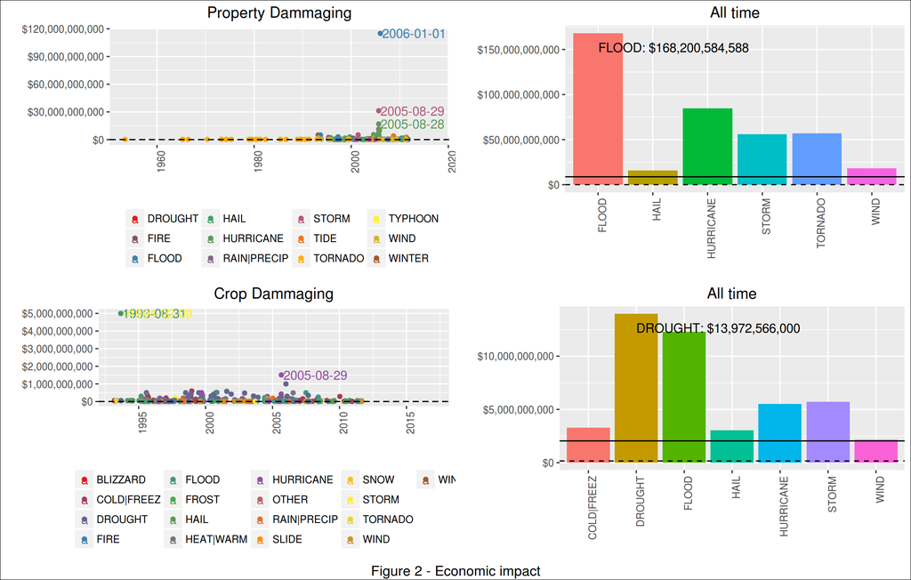

```r
grid.arrange(plt.prop.single, plt.prop.all,
             plt.crop.single, plt.crop.all,
             nrow=2, ncol=2,
             bottom="Figure 2 - Economic impact")
grid.rect(gp=gpar(fill=NA))
```

## Results

### Population Health

The single most fatal event was a **HEAT|WARM, that occurred in IL, ILZ003>00, on 1995-07-12, killing 583 people.**

The most fatal event along the time is the **TORNADO. It has killed 5636 people until now.**

The single most injuring event was a **TORNADO, that occurred in TX, WICHITA, on 1979-04-10, injuring 1700 people.**

The most injuring event along the time is the **TORNADO. It has injuried 91407 people until now.**

### Economic Damages

The single most economic damaging event to properties was a **FLOOD, that occurred in CA, NAPA, on 2006-01-01, causing U$ $115,000,000,000 in losses**.

The most property damaging event along the time is the **FLOOD. It has caused $168,200,584,588 in losses.**

The single most economic damaging event to crops was a **FLOOD, that occurred in IL, ADAMS, CA, on 1993-08-31, causing U$ $5,000,000,000 in losses**.

The most crop damaging event along the time is the **DROUGHT. It has caused $13,972,566,000 in losses.**

## Distribution of data

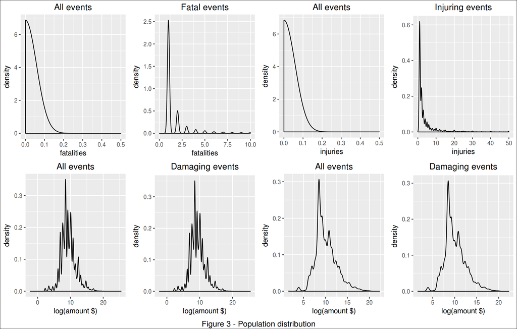

```r
grid.arrange(plt.distr.fatal0, plt.distr.fatal1, plt.distr.inj0, plt.distr.inj1,
             plt.distr.prop0, plt.distr.prop1, plt.distr.crop0, plt.distr.crop1,
             nrow=2, ncol=4,
             bottom="Figure 3 - Population distribution")
grid.rect(gp=gpar(fill=NA))
```